# Seamless task switching ERPs: project comparison

Jussi Korpela

June 18, 2018

```r
# Set up RMarkdown working directory & some options

# Working directory for easy sourcing of helper functions
#R_BASE_DIR <- "/home/jkor/work_local/projects/seamless/github/R"
#repo_dir <- '/home/jussi/work_local/projects/core/github/R'
R_BASE_DIR <- params$r_base_dir
knitr::opts_knit$set(root.dir = normalizePath(R_BASE_DIR))

# Set general options
knitr::opts_knit$set(echo = TRUE,
                     fig.align = "center")
```

# Objective

Plot ERPs and related infromation. Plot extracted amplitudes and latencies (features) as well. A preliminary analysis to see if the are any effects in the data.

# TODO

- Double check how peak averaging windows etc. have been defined? Same windows for both projects or not?
- LME4 analyses: MBI cutoff (1.5 / 2.5)
- LME4 analyses: How to wrap up?

# Setup

Configurations for this analysis. To see them, tap open the code block.

```r
## Setup
source("init_jkor.R")
source("tools_dataload.R")

require(cowplot)
#require(plotly)
require(DT)


# PROJECT_ROOT_PATH <- '/ukko/projects/SeamlessCare_2015-16/'
PROJECT_ROOT_PATH <- params$project_root_path

PATHS <- create_ctap_paths(PROJECT_ROOT_PATH, 'tmp')


CHANNEL_ARR <- c('Fz','Cz','Pz')
PATH_PATTERNS <- c("src-1_ica", "src-1_blinkICfix", "src-1_blinkICremove")
BRANCHES <- c('asis', 'BLICfix', 'BLICremove')
MBI_CUTOFF <- 1.49

FIG_WIDTH <- 15
OUT_WIDTH_FC <- 15*100

SEAM_INPUT_PATH <- file.path(PATHS$project_root, 'analysis', 'ctap_tswitch_results', 'rds')
UUPU_INPUT_PATH <- file.path(PATHS$project_root, 'analysis', 'ctap_tswitch_uupu_results', 'rds')
SBJD_INPUT_PATH = file.path(PATHS$project_root, 'data', 'taustatiedot')
```

Setup summary:

- dataset 1: /ukko/projects/SeamlessCare_2015-16//analysis/ctap_tswitch_results/rds
- dataset 2: /ukko/projects/SeamlessCare_2015-16//analysis/ctap_tswitch_uupu_results/rds

# Data

## Subject related metadata

```r
sbj_factor_file = file.path(SBJD_INPUT_PATH, 'uupu_seam_metadata.rds')
sbjf = as_tibble(readRDS(sbj_factor_file))

sbjf = sbjf %>%
  rename(sbjnr = subjnr) %>%
  mutate(sbjnr = as.integer(sbjnr))
```

```r
mbiage <- sbjf %>%
  select(sbjnr, project, MBIScore, age) %>%
  gather('variable', 'value', one_of('MBIScore','age')) %>%
  unite(pvar, variable, project) %>%
  spread(pvar, value)
head(mbiage)
```

```
## # A tibble: 6 x 5
##   sbjnr age_SEAM age_UUPU MBIScore_SEAM MBIScore_UUPU
##   <int>    <dbl>    <dbl>         <dbl>         <dbl>
## 1     2      40.      35.          2.01         0.960
## 2     3      NA       36.         NA            4.46
## 3     4      NA       61.         NA            4.17
## 4     5      53.      48.          4.55         4.96
## 5     6      NA       42.         NA            2.17
## 6     7      NA       34.         NA            1.36
```

```r
# Define groups

mbiage$mbigroup = 'unknown' #column to keep track of how MBIScore has developed
MBI_TH = 1.49

match1 = (mbiage$MBIScore_SEAM > MBI_TH) & (mbiage$MBIScore_UUPU > MBI_TH)
mbiage$mbigroup[match1] = 'high'

match2 = (mbiage$MBIScore_SEAM <= MBI_TH) & (mbiage$MBIScore_UUPU <= MBI_TH)
mbiage$mbigroup[match2] = 'low'

match3 = (mbiage$MBIScore_UUPU <= MBI_TH) & (mbiage$MBIScore_SEAM > MBI_TH)
mbiage$mbigroup[match3] = 'low -> high'

match4 = (mbiage$MBIScore_UUPU > MBI_TH) & (mbiage$MBIScore_SEAM <= MBI_TH)
mbiage$mbigroup[match4] = 'high -> low'

mbiage %>% group_by(mbigroup) %>% count()
```

```
## # A tibble: 5 x 2
## # Groups:   mbigroup [5]
##   mbigroup        n
##   <chr>       <int>
## 1 high           18
## 2 high -> low     3
## 3 low             8
## 4 low -> high     2
## 5 unknown        36
```

```r
mbiage <- mbiage %>%
  mutate(age = (age_SEAM + age_UUPU)/2)
```

Add mbigroup to subject data.

```r
sbjf <- left_join(sbjf,
                  mbiage %>% select(sbjnr, mbigroup),
                  by = 'sbjnr')
```

There is one missing data point in key subject related variables:

```r
sum(is.na(sbjf %>% select(age, MBIScore, BDI2, BAI)))
```

```
## [1] 1
```

Impute missing values using group averages:

```r
# Replace with group mean
my_imputation <- function(ds){
  cvar <- 'BDI2'
  na.match <- is.na(ds[[cvar]])
  ds[na.match] <- mean(ds[[cvar]], na.rm = T)
  ds
}

sbjf <- sbjf %>%
  group_by(project, mbigroup) %>%
  do(my_imputation(.)) %>%
  ungroup()
```

## ERP feature data

The raw data consists of subject average ERPs stored as HDF5 files by the CTAP analysis pipe. These are collected into an R -dataset by a separate script `tswitch_prepare_erpfeat.R`. Also ERP features such as amplitude and latency are extracted by the same script and stored to disk for fast access.

Let’s first load all this data for both projects and combine.

```r
erpf1 = readRDS(file.path(SEAM_INPUT_PATH, 'TS03_erpfeat.rds'))
erpf1$project = 'SEAM'
erpf2 = readRDS(file.path(UUPU_INPUT_PATH, 'TS03_erpfeat.rds'))
erpf2$project = 'UUPU'

# Combine + add subject number (to tell apart cardiovasculars)
erpf = bind_rows(erpf1, erpf2) %>%
  mutate(sbjnr = as.integer(str_replace_all(subject, '[A-Z]', '')),
         project = ordered(project, levels = c('UUPU','SEAM')) )


# Combine ERP feature and subject data

## MBI group and mean age (independent of project)
erpf <- left_join(erpf,
                  mbiage %>% select(sbjnr, mbigroup, age),
                  by = 'sbjnr')

## MBIScore, BDI2, BAI (vary between projects)
erpf <- left_join(erpf,
                  sbjf %>% select(subject, MBIScore, BDI2, BAI),
                  by = 'subject')
```

## Filter

```r
#MBIG_LEVELS = c('low', 'high','low -> high','high -> low')
MBIG_LEVELS = c('low', 'high')
erpf <- erpf %>%
  filter(mbigroup %in% MBIG_LEVELS, sbjnr < 100) %>%
  mutate(mbigroup = ordered(mbigroup, levels = MBIG_LEVELS ))
```

There are 0 missing values in `erpf`.

Rename columns to match MMN analysis such that MMN LME models can be applied direclty:

```r
erpf <- erpf %>%
  rename(subjectid = subject) %>%
  mutate(subject = sbjnr)
```

## Aggregate feature values (for plotting)

```r
erpagg <- erpf %>%
  group_by(project,mbigroup,erpid,comp,channel,variable) %>%
  summarise(n = n(), mean = mean(value), sd = sd(value), se = sd / sqrt(n))
```

# Visualize

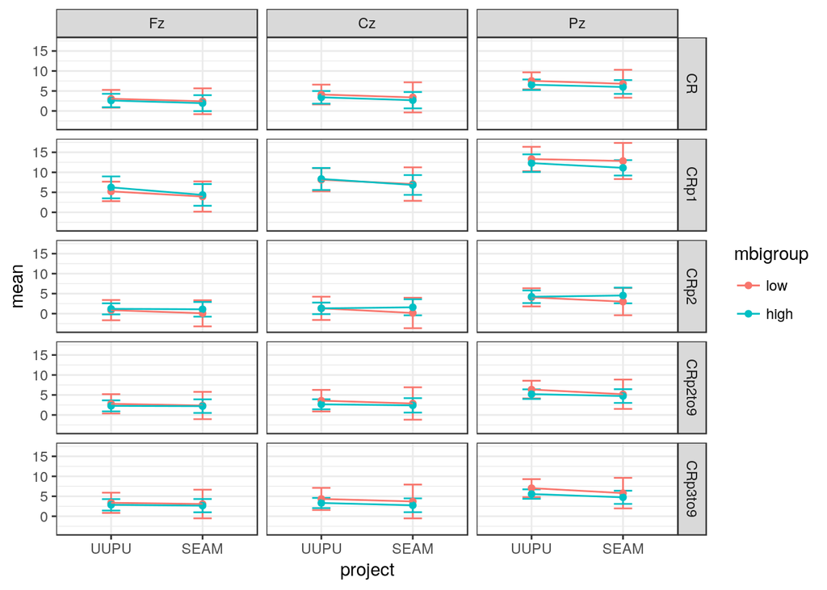

```r
my_interaction_plot <- function(pd){
  p <- ggplot(pd, aes(x = project, y = mean, color = mbigroup)) +
  geom_errorbar(aes(ymin = mean - 1.96*se, ymax = mean + 1.96*se),
                width = 0.2) +
  geom_point() +
  geom_line(aes(group = mbigroup)) +
  scale_color_discrete() +
  theme_bw() +
  facet_grid(erpid ~ channel)
  p
}

pd <- erpagg %>%
  filter(comp == 'P3a', variable == 'amplitude', mbigroup %in% c('low','high'))
p <- my_interaction_plot(pd)
p
```

### Amplitude - P3b

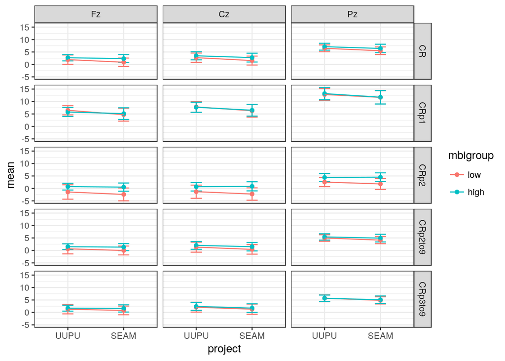

```r
pd <- erpagg %>%
  filter(comp == 'P3b', variable == 'amplitude', mbigroup %in% c('low','high'))
p <- my_interaction_plot(pd)
p
```

### Latency - P3a

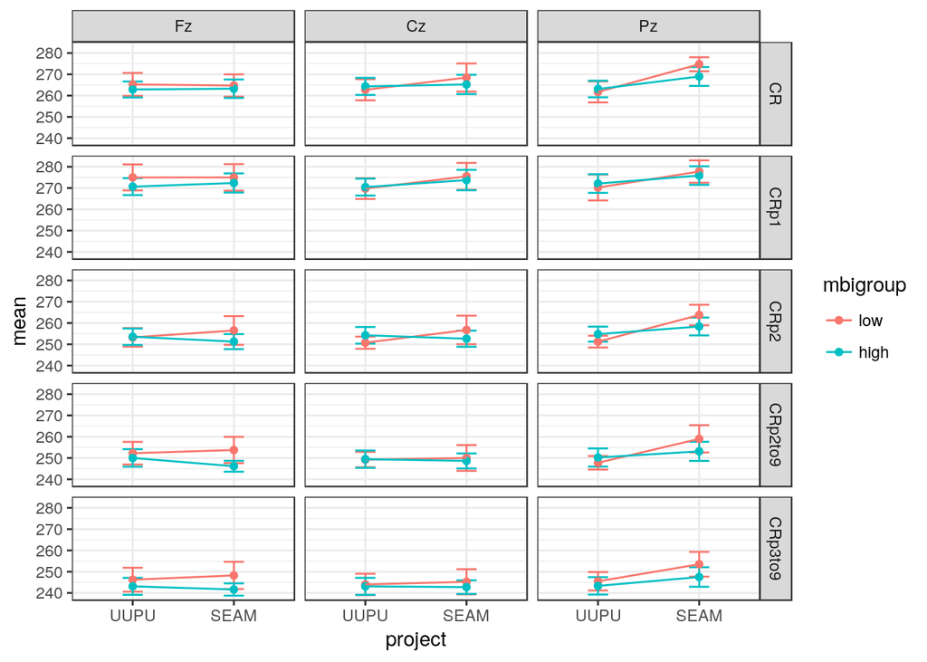

```r
pd <- erpagg %>%
  filter(comp == 'P3a', variable == 'latency', mbigroup %in% c('low','high'))
p <- my_interaction_plot(pd)
p
```

### Latency - P3b

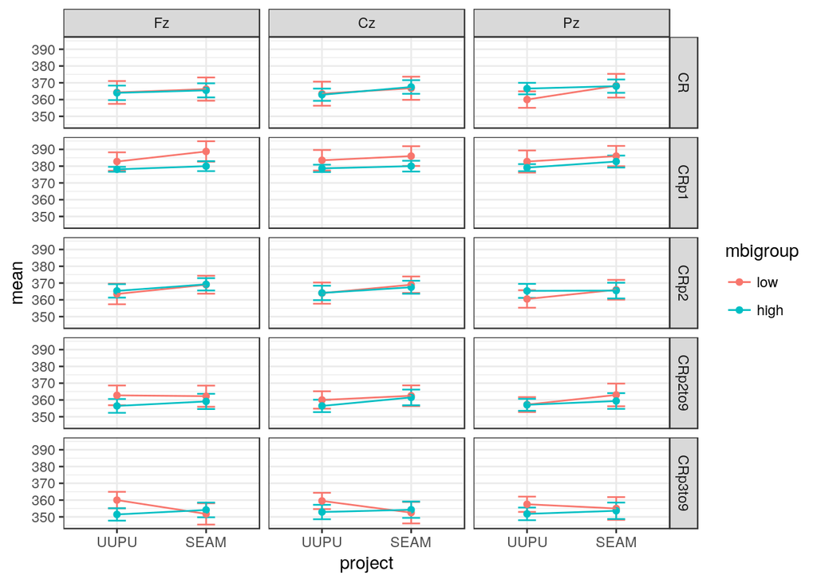

```r
pd <- erpagg %>%
  filter(comp == 'P3b', variable == 'latency', mbigroup %in% c('low','high'))
p <- my_interaction_plot(pd)
p
```

# Linear Mixed Models (LMMs)

```r
erpfn <- erpf %>%
  group_by(erpid, comp, variable) %>%
  nest()

#erpfn[1,'data'][[1]][[1]]


require(lme4)
require(lmerTest)
```

```r
source("mmn/lmm_models.R")
source("tswitch/tswitch_lmm_models.R")

# cmodel <- lmm_ia_chbdibai()
# cdata <- as.data.frame(erpfn[1,'data'][[1]])
# res <- eval_model(cmodel, cdata, p_method = "satterthwaite")

# cmodf <- function(ds){
#   eval_model(lmm_ia_chbdibai(), ds, p_method = "satterthwaite")
# }
#
# modres <- map(erpfn$data, cmodf)
# erpfn$modres <- modres

# Wrap model specifications into a function that accepts the data as input and
# returns a list of results
make_model_func <- function(model_list){
  function(ds){
    eval_model(model_list, ds, p_method = "satterthwaite")
  }
}

cmodf1 <- make_model_func(lmm_ia_chbdibai())
modres1 <- map(erpfn$data, cmodf1)

cmodf2 <- make_model_func(lmm_ia_ch())
modres2 <- map(erpfn$data, cmodf2)

cmodf3 <- make_model_func(lmm_me_chbdibai())
modres3 <- map(erpfn$data, cmodf3)

cmodf4 <- make_model_func(lmm_me_ch())
modres4 <- map(erpfn$data, cmodf4)
```

## Plot goodness of fit (GOF) values

```r
make_gof_pd <- function(erpfn, modres){
  gof_pd <- bind_cols(erpfn %>% select(-data),
                    tibble(a = map(modres, function(el){el$gof})) %>% unnest())
  gof_pd <- gof_pd %>%
    gather('gof', 'value', one_of(c(names(modres[[1]]$gof))) )
  gof_pd$model <- modres[[1]]$model$description
  gof_pd
}

gof_pd <- bind_rows(
  map(list(modres1, modres2, modres3, modres4),
          function(lel){make_gof_pd(erpfn, lel)})
  )
head(gof_pd)
```

```
## # A tibble: 6 x 6
##   erpid comp  variable  gof   value model
##   <chr> <chr> <chr>     <chr> <dbl> <chr>
## 1 CR    P3a   amplitude AIC    673. lmm_ia_chbdibai
## 2 CR    P3a   latency   AIC   1008. lmm_ia_chbdibai
## 3 CR    P3b   amplitude AIC    622. lmm_ia_chbdibai
## 4 CR    P3b   latency   AIC   1031. lmm_ia_chbdibai
## 5 CRp1  P3a   amplitude AIC    785. lmm_ia_chbdibai
## 6 CRp1  P3a   latency   AIC   1009. lmm_ia_chbdibai
```

### P3a - amplitude

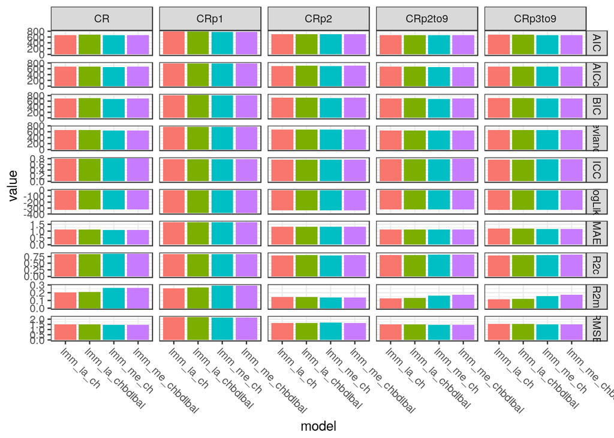

```r
my_gof_plot <- function(pd){
  p <- ggplot(pd, aes(x = model, y = value, fill = model)) +
  geom_col() +
  scale_color_discrete() +
  theme_bw() +
  facet_grid(gof ~ erpid, scales = 'free_y') +
  theme(axis.text.x = element_text(angle = -45, hjust = 0),
        legend.position = "none")
  p
}

pd <- gof_pd %>% filter(comp == 'P3a', variable == 'amplitude')
p <- my_gof_plot(pd)
p
```

### P3b - amplitude

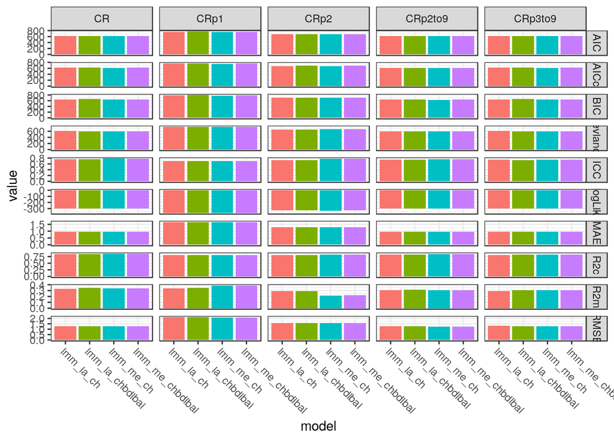

```r
pd <- gof_pd %>% filter(comp == 'P3b', variable == 'amplitude')
p <- my_gof_plot(pd)
p
```

### P3a - latency

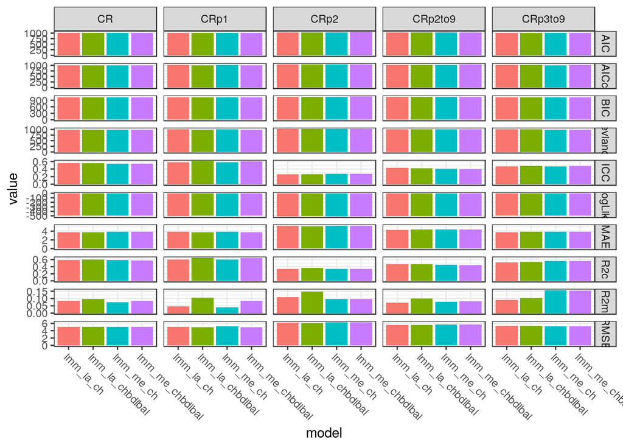

```r
pd <- gof_pd %>% filter(comp == 'P3a', variable == 'latency')
p <- my_gof_plot(pd)
p
```

### P3b - latency

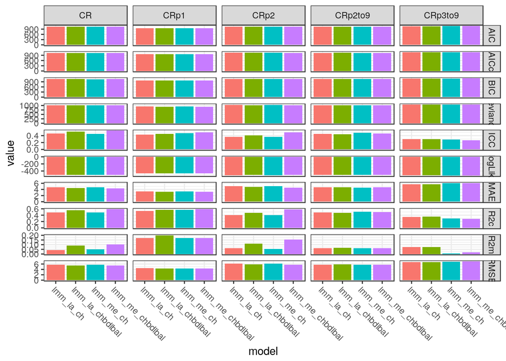

```r
pd <- gof_pd %>% filter(comp == 'P3b', variable == 'latency')
p <- my_gof_plot(pd)
p
```

### Plot significant components

```r
ALPHA <- 0.05

make_fsig_pd <- function(erpfn, modres){
  fsig_pd <- erpfn %>%
    select(-data) %>%
    mutate(fsig = map(modres, function(el){el$fsig}),
           model = modres[[1]]$model$description) %>%
    unnest(fsig)
  fsig_pd
}

tmp <- make_fsig_pd(erpfn, modres2)

fsig_pd <- bind_rows(
  map(list(modres1, modres2, modres3, modres4),
          function(lel){make_fsig_pd(erpfn, lel)})
  ) %>%
  mutate(is_signif = p < ALPHA)

head(fsig_pd)
```

```
## # A tibble: 6 x 10
##   erpid comp  variable  model  fname  NumDF DenDF      p F.value is_signif
##   <chr> <chr> <chr>     <chr>  <chr>  <int> <dbl>  <dbl>   <dbl> <lgl>
## 1 CR    P3a   amplitude lmm_i… mbigr…     1   37. 1.00   5.00e-3 FALSE
## 2 CR    P3a   amplitude lmm_i… proje…     1  124. 0.0881 4.86e+0 FALSE
## 3 CR    P3a   amplitude lmm_i… chann…     2  124. 0.     9.02e+1 TRUE
## 4 CR    P3a   amplitude lmm_i… BDI2       1  149. 1.00   2.94e-1 FALSE
## 5 CR    P3a   amplitude lmm_i… BAI        1  138. 0.864  1.14e+0 FALSE
## 6 CR    P3a   amplitude lmm_i… mbigr…     1  127. 1.00   7.00e-3 FALSE
```

### Amplitude - P3a

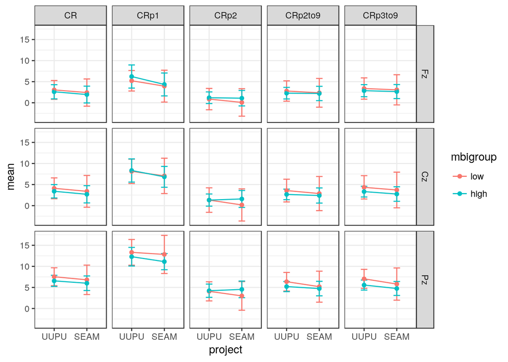

```r
my_interaction_plot2 <- function(pd){
  p <- ggplot(pd, aes(x = project, y = mean, color = mbigroup)) +
  geom_errorbar(aes(ymin = mean - 1.96*se, ymax = mean + 1.96*se),
                width = 0.2) +
  geom_point() +
  geom_line(aes(group = mbigroup)) +
  scale_color_discrete() +
  theme_bw() +
  facet_grid(channel ~ erpid)
  p
}

pd <- erpagg %>%
  filter(comp == 'P3a', variable == 'amplitude', mbigroup %in% c('low','high'))
p <- my_interaction_plot2(pd)
p
```

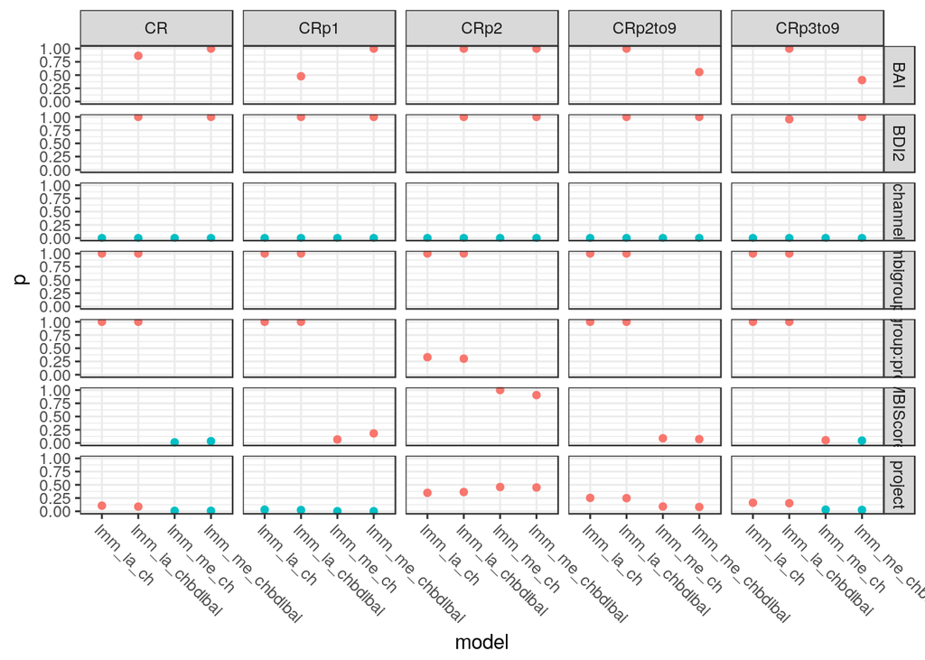

```r
my_fsig_plot <- function(pd){
  p <- ggplot(pd, aes(x = model, y = p, color = is_signif)) +
    geom_point() +
    scale_color_discrete() +
    theme_bw() +
    scale_y_continuous(limits = c(0,1)) +
    facet_grid(fname ~ erpid, scales = 'free_y') +
    theme(axis.text.x = element_text(angle = -45, hjust = 0),
          legend.position = "none")
  p
}

pd <- fsig_pd %>% filter(comp == 'P3a', variable == 'amplitude')
p <- my_fsig_plot(pd)
p
```

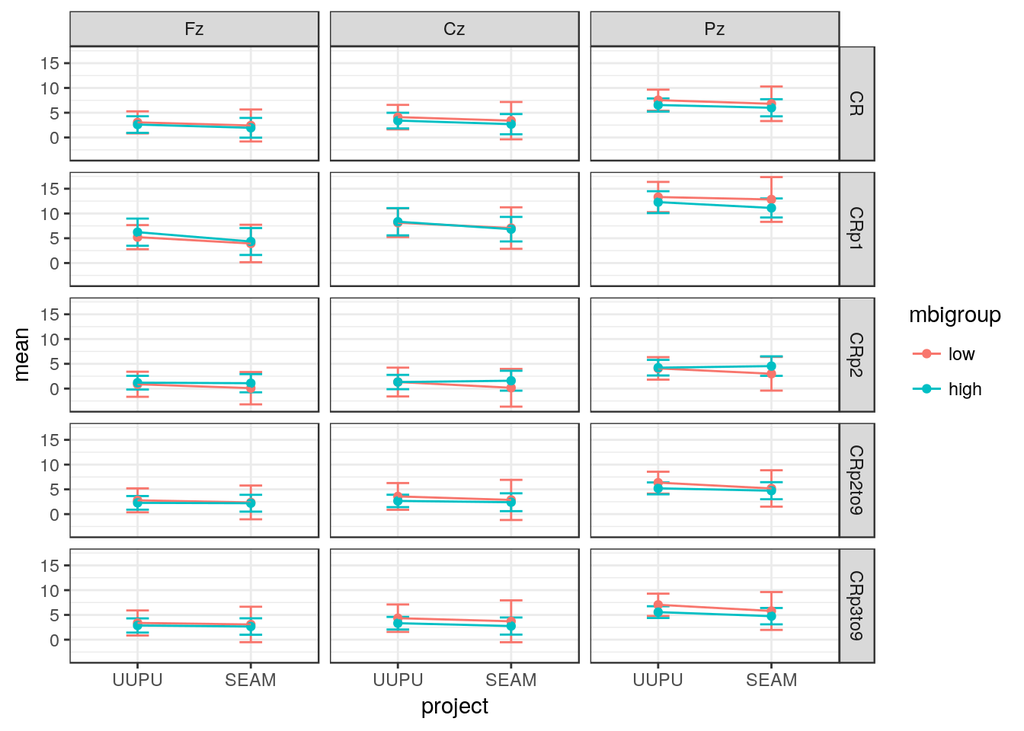

```r
pd <- erpagg %>%
  filter(comp == 'P3a', variable == 'amplitude', mbigroup %in% c('low','high'))
p <- my_interaction_plot(pd)
p
```

### Amplitude - P3b

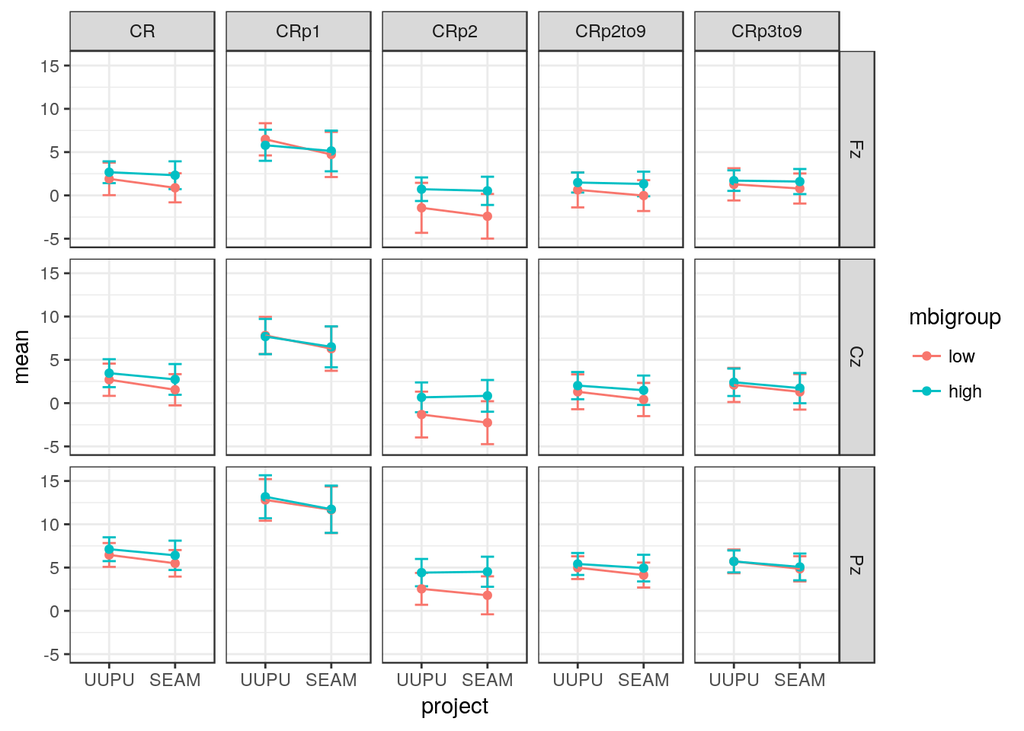

```r
pd <- erpagg %>%
  filter(comp == 'P3b', variable == 'amplitude', mbigroup %in% c('low','high'))
p <- my_interaction_plot2(pd)
p
```

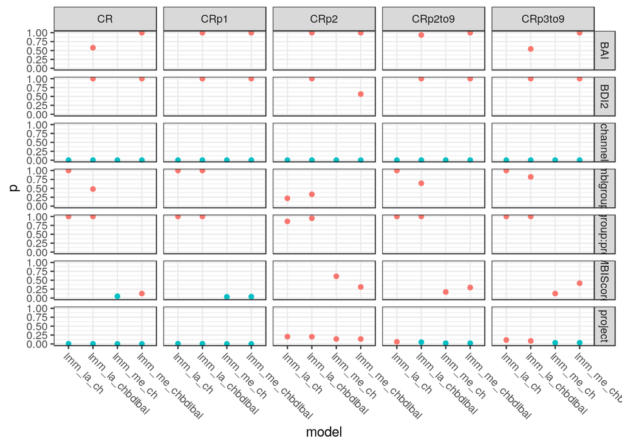

```r
pd <- fsig_pd %>% filter(comp == 'P3b', variable == 'amplitude')
p <- my_fsig_plot(pd)
p
```

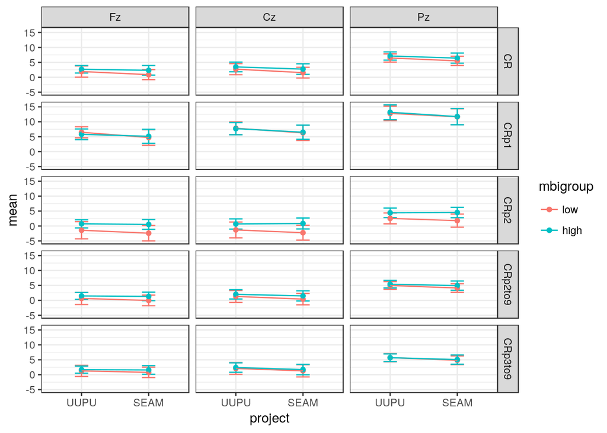

```r
pd <- erpagg %>%
  filter(comp == 'P3b', variable == 'amplitude', mbigroup %in% c('low','high'))
p <- my_interaction_plot(pd)
p
```

### Latency - P3a

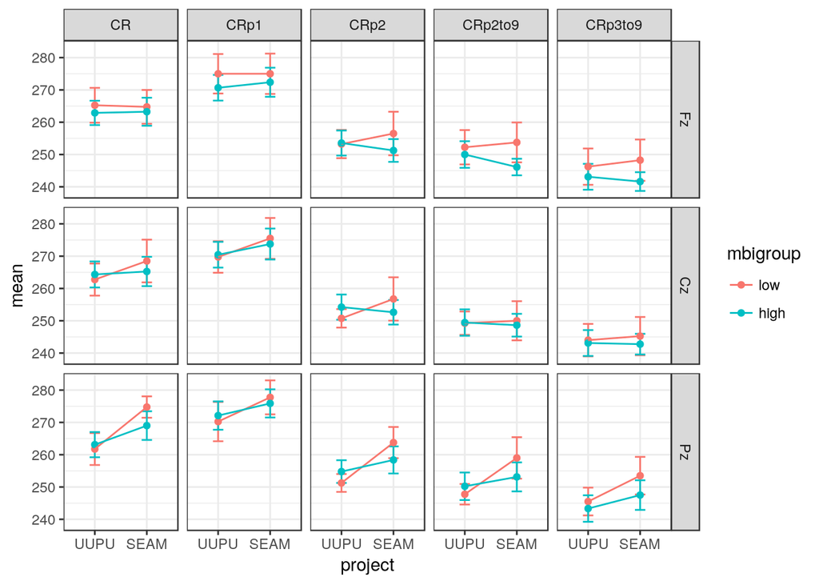

```r
pd <- erpagg %>%
  filter(comp == 'P3a', variable == 'latency', mbigroup %in% c('low','high'))
p <- my_interaction_plot2(pd)
p
```

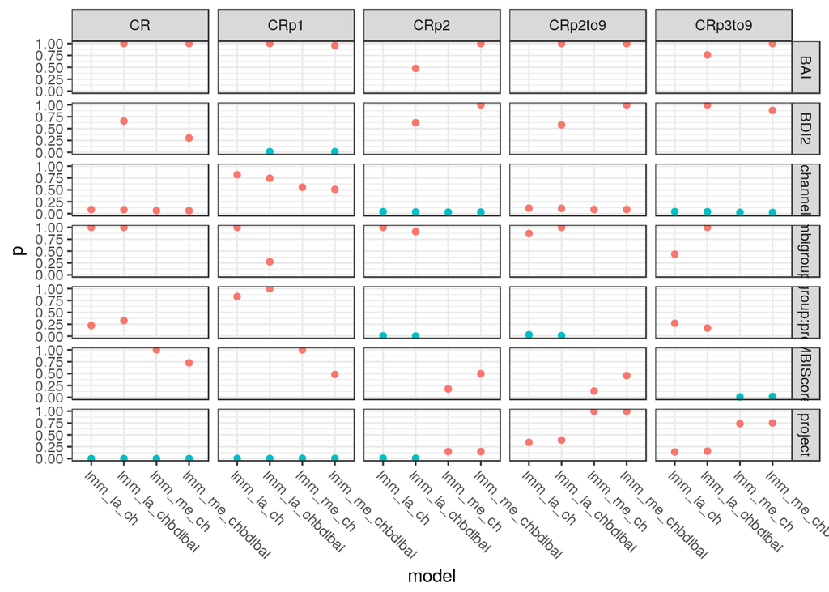

```r
pd <- fsig_pd %>% filter(comp == 'P3a', variable == 'latency')
p <- my_fsig_plot(pd)
p
```

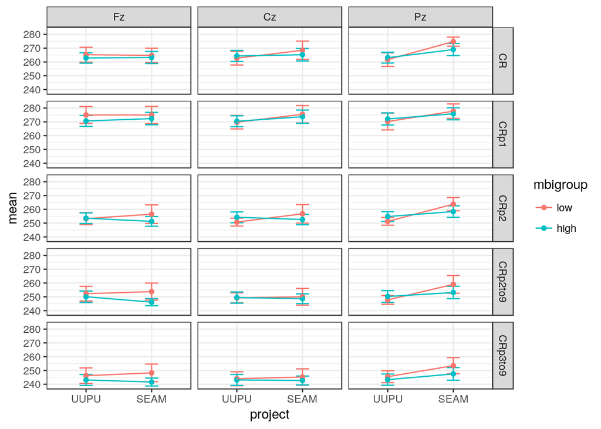

```r
pd <- erpagg %>%
  filter(comp == 'P3a', variable == 'latency', mbigroup %in% c('low','high'))
p <- my_interaction_plot(pd)
p
```

### Latency - P3b

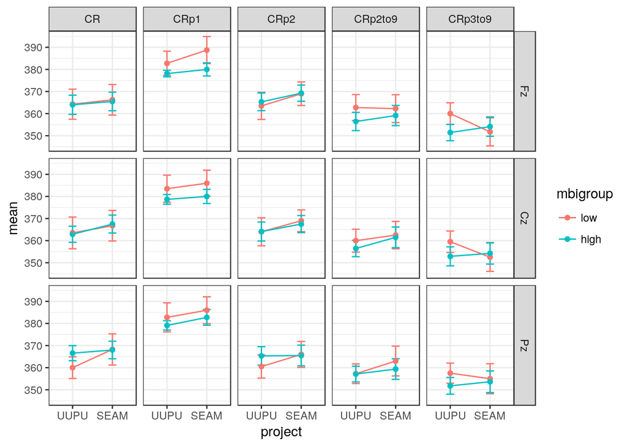

```r
pd <- erpagg %>%
  filter(comp == 'P3b', variable == 'latency', mbigroup %in% c('low','high'))
p <- my_interaction_plot2(pd)
p
```

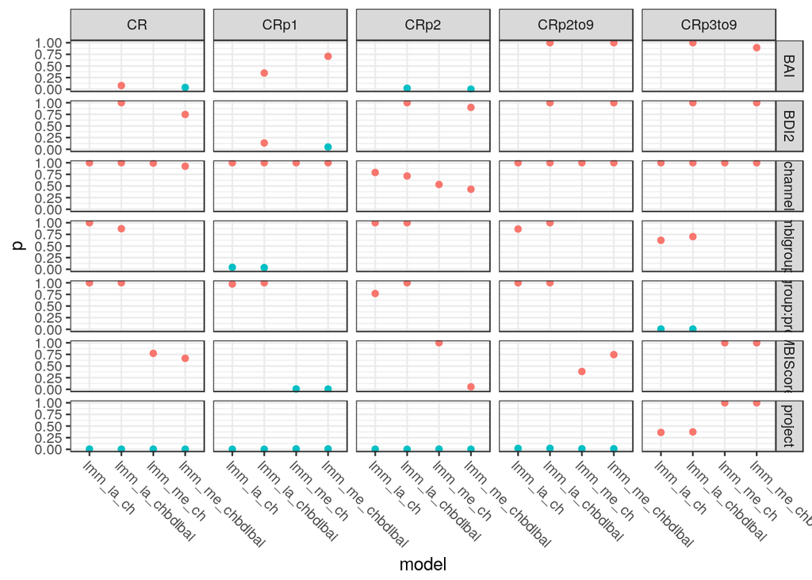

```r
pd <- fsig_pd %>% filter(comp == 'P3b', variable == 'latency')
p <- my_fsig_plot(pd)
p
```

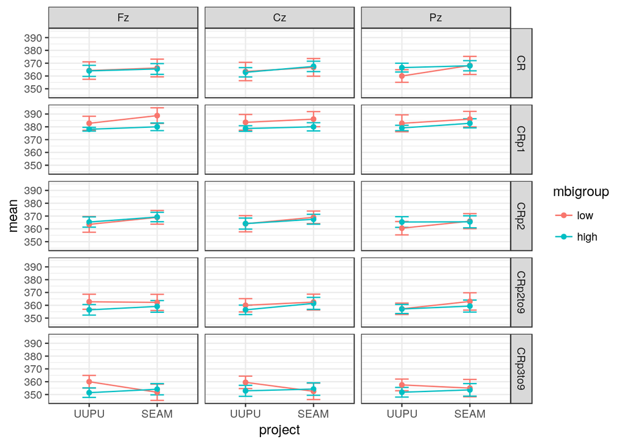

```r
pd <- erpagg %>%
  filter(comp == 'P3b', variable == 'latency', mbigroup %in% c('low','high'))
p <- my_interaction_plot(pd)
p
```